# Stat 115 Lab 9

HMM, Linear Regression, LASSO

Andy Shi

March 27-29, 2018

## Outline of HW5

1. Hidden Markov Model
   - Implement forward-backward and viterbi algorithm
   - Compare with R implementation
   - HMM conceptual question
2. Python programming
   - Parse a tab-delimited file
   - Similar to Python part in HW4
3. Feature Selection & Epigenetic Gene Regulation
   - Writing a small Python parsing script
   - Linear regression
   - PCA
   - LASSO

## Outline of Lab

1. Fitting Hidden Markov Model
2. Fitting linear regression
3. Fitting LASSO
4. If time/interest: debugging using a debugger
   - PDB for Python
   - RStudio built-in debugger for R

## Install and Load Packages

```r
# install packages from bioconductor
#source("https://bioconductor.org/biocLite.R")
install.packages("HMM")
install.packages("glmnet")
# etc.
```

```r
library(HMM)
library(glmnet)
```

## Hidden Markov Model Description

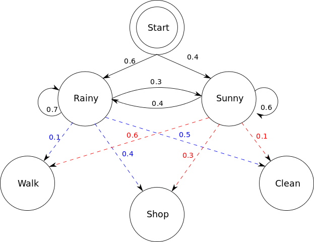

## Fitting it in R: Setup

- Have to initialize an HMM object

```r
transProbs <- matrix(c(0.7, 0.4, 0.3, 0.6), nrow = 2)
emissionProbs <- matrix(c(0.1, 0.6, 0.4, 0.3, 0.5, 0.1), nrow = 2)
startProbs <- c(0.6, 0.4)
hmm <- initHMM(c("Rainy","Sunny"), c("Walk","Shop", "Clean"),
               startProbs, transProbs, emissionProbs)
print(hmm)
```

```
## $States
## [1] "Rainy" "Sunny"
##
## $Symbols
## [1] "Walk"  "Shop"  "Clean"
##
## $startProbs
## Rainy Sunny
##   0.6   0.4
##
## $transProbs
##        to
## from    Rainy Sunny
##   Rainy   0.7   0.3
##   Sunny   0.4   0.6
##
## $emissionProbs
##        symbols
## states  Walk Shop Clean
##   Rainy  0.1  0.4   0.5
##   Sunny  0.6  0.3   0.1
```

```r
# Sequence of observations
observations = c("Clean", "Shop", "Walk")
```

## Forward-Backward

- Forward ($\alpha$): Pr(state at time k is X, and observe obs 1 to k)
- Backward: At time k, Pr(observe obs k+1 to end | state is X)
- Posterior: P(state at time k is X | all observations)

```r
exp(forward(hmm, observations))
```

```
##        index
## states     1      2        3
##   Rainy 0.30 0.0904 0.007696
##   Sunny 0.04 0.0342 0.028584
```

```r
exp(backward(hmm, observations))
```

```
##        index
## states      1    2 3
##   Rainy 0.106 0.25 1
##   Sunny 0.112 0.40 1
```

```r
posterior(hmm, observations)
```

```
##        index
## states         1         2         3
##   Rainy 0.876516 0.6229327 0.2121279
##   Sunny 0.123484 0.3770673 0.7878721
```

## Viterbi

- Most likely path
- Takes into account dependency between states

```r
viterbi(hmm, observations)
```

```
## [1] "Rainy" "Rainy" "Sunny"
```

## Linear Regression

- Objective: find best-fit line to data.
- For each subject $i$, observe outcome $Y_i$ and vector of covariates $X_i$.
- Math version:
  $$\min_{\beta} \sum_{i = 1}^n (Y_i - X_i \beta)^2$$
- $\hat{\beta} = (X^T X)^{-1} X^T Y$

## Linear Regression Example with DataFrames

```r
# 1 covariate
mod1 <- lm(mpg ~ wt, data = mtcars)
mod1
```

```
##
## Call:
## lm(formula = mpg ~ wt, data = mtcars)
##
## Coefficients:
## (Intercept)           wt
##      37.285       -5.344
```

```r
# multiple covariates
mod2 <- lm(mpg ~ wt + cyl, data = mtcars)
mod2
```

```
##
## Call:
## lm(formula = mpg ~ wt + cyl, data = mtcars)
##
## Coefficients:
## (Intercept)           wt          cyl
##      39.686       -3.191       -1.508
```

## Linear Regression Example with Vectors

```r
mpg <- mtcars$mpg
wt <- mtcars$wt
mod3 <- lm(mpg ~ wt)
mod3
```

```
##
## Call:
## lm(formula = mpg ~ wt)
##
## Coefficients:
## (Intercept)           wt
##      37.285       -5.344
```

## LASSO

- Remember for linear regression we try to optimize:
  $$\min_{\beta} \sum_{i = 1}^n (Y_i - X_i \beta)^2$$
- Run into problems when there are too many covariates: $(X^T X)$ not invertible
- LASSO’s solution: penalize $\beta$ for being too big. Optimize:
  $$\min_{\beta} \sum_{i = 1}^n (Y_i - X_i \beta)^2 + \lambda \sum_{j = 1}^p |\beta_j|$$
- Has the additional effect of setting some $\beta_j = 0$—feature selection!
- Remember to normalize your data! Ex: weight could be measured in kg or g, which would change the magnitude of the coefficient. Can avoid by normalizing so each covariate has mean 0 and variance 1.

## LASSO in R

```r
data(QuickStartExample) # from glmnet package
head(x, 3)
```

```
##            [,1]       [,2]       [,3]       [,4]       [,5]      [,6]
## [1,]  0.2738562 -0.0366722  0.8547269  0.9675242  1.4154898 0.5234059
## [2,]  2.2448169 -0.5460300  0.2340651 -1.3350304  1.3130758 0.5212746
## [3,] -0.1254230 -0.6068782 -0.8539217 -0.1487772 -0.6646828 0.6066164
##            [,7]       [,8]       [,9]     [,10]      [,11]       [,12]
## [1,]  0.5626882  1.1112233  1.6408214 0.6187067  0.9999348 -0.07841916
## [2,] -0.6100346 -0.8613965 -0.2704635 0.2300825 -0.1057090  0.16314122
## [3,]  0.1617207 -0.8627217  0.6042102 1.1939768  0.5012509 -0.94520592
##           [,13]       [,14]      [,15]      [,16]      [,17]       [,18]
## [1,] -0.6033261  0.03323168 -0.7008845  1.1578379  1.4578156  0.77490699
## [2,]  0.7620766  0.67812003 -0.5282670 -0.8791548 -0.4729134 -1.11717309
## [3,]  0.3989026 -0.76478505  1.2854019  0.6448767  0.1792455  0.04473756
##           [,19]      [,20]
## [1,] -1.2685177  1.9935800
## [2,] -0.7377321 -1.0787929
## [3,]  1.1053071  0.3040545
```

```r
head(y)
```

```
##            [,1]
## [1,] -1.2748860
## [2,]  1.8434251
## [3,]  0.4592363
## [4,]  0.5640407
## [5,]  1.8729633
## [6,]  0.5275317
```

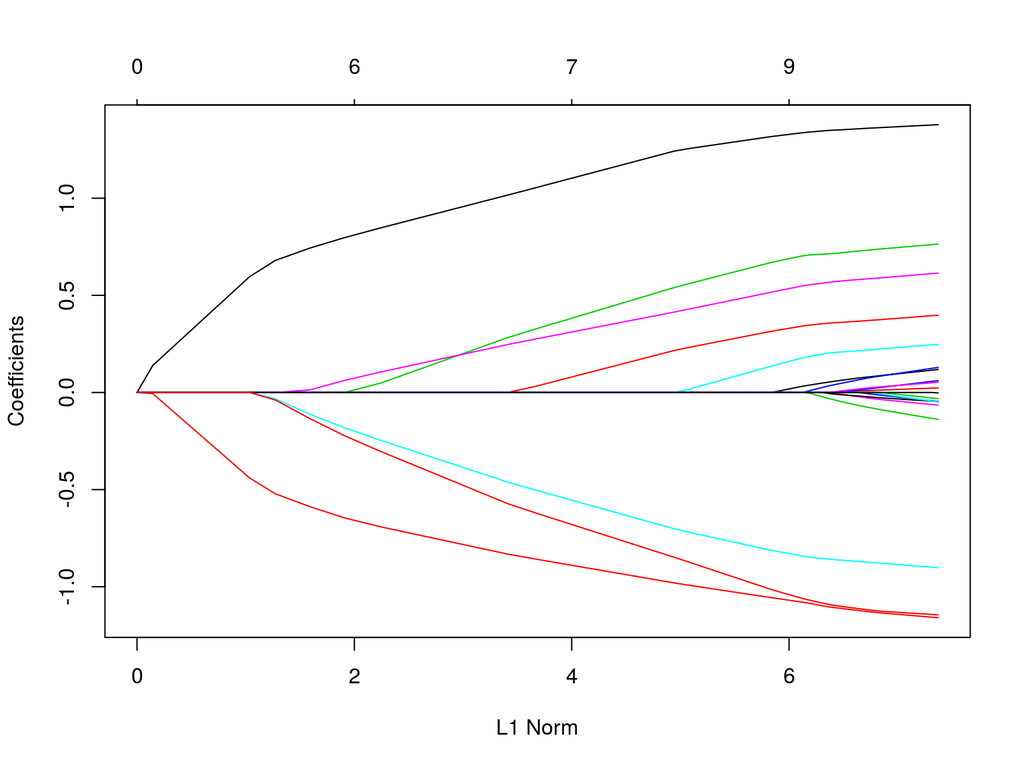

```r
fit <- glmnet(x, y)
plot(fit)
```

```r
coef(fit, s = 0.1)
```

```
## 21 x 1 sparse Matrix of class "dgCMatrix"
##                        1
## (Intercept)  0.150928072
## V1           1.320597195
## V2           .
## V3           0.675110234
## V4           .
## V5          -0.817411518
## V6           0.521436671
## V7           0.004829335
## V8           0.319415917
## V9           .
## V10          .
## V11          0.142498519
## V12          .
## V13          .
## V14         -1.059978702
## V15          .
## V16          .
## V17          .
## V18          .
## V19          .
## V20         -1.021873704
```

## Picking $\lambda$: Cross-Validation

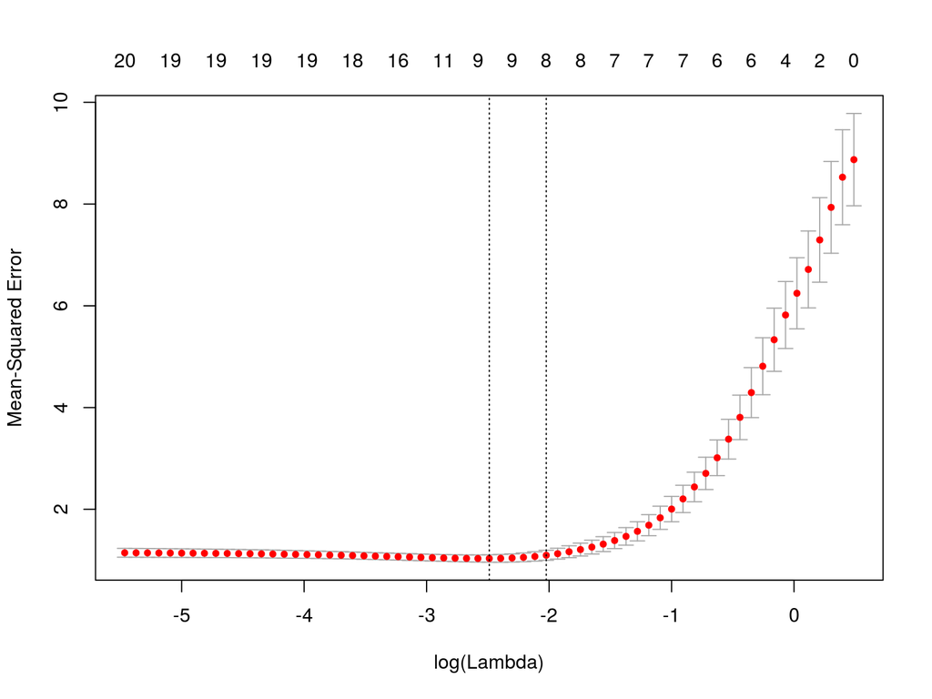

```r
cvfit <- cv.glmnet(x, y)
plot(cvfit)
```

```r
# min lambda
cvfit$lambda.min
```

```
## [1] 0.08307327
```

```r
# coefficients for min lambda
coef(cvfit, s = "lambda.min")
```

```
## 21 x 1 sparse Matrix of class "dgCMatrix"
##                       1
## (Intercept)  0.14936467
## V1           1.32975267
## V2           .
## V3           0.69096092
## V4           .
## V5          -0.83122558
## V6           0.53669611
## V7           0.02005438
## V8           0.33193760
## V9           .
## V10          .
## V11          0.16239419
## V12          .
## V13          .
## V14         -1.07081121
## V15          .
## V16          .
## V17          .
## V18          .
## V19          .
## V20         -1.04340741
```

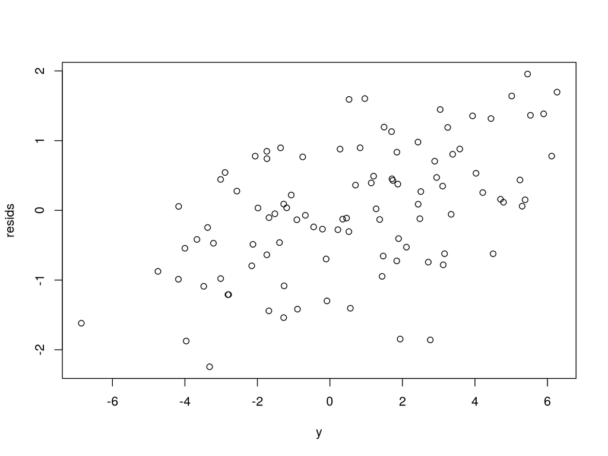

```r
# residuals for min lambda
resids <- y - predict(cvfit, newx = x, s = "lambda.min")
plot(y, resids)
```

## Debugging with Debugger

- Easier / better than using print statements.
- R in RStudio: https://support.rstudio.com/hc/en-us/articles/205612627-Debugging-with-RStudio
- Python: https://docs.python.org/2/library/pdb.html
- Example adapted from: https://pythonconquerstheuniverse.wordpress.com/2009/09/10/debugging-in-python/